# Joseph (Joey) Michael Hulbert

WSU Urban Forest Health Lab, Puyallup Research and Extension Center, Washington State University, 2606 West Pioneer, Puyallup, WA, 98371-4998 https://jmhulbert.github.io 1-541-908-5129 hulbe@wsu.edu [Curriculum Vitae PDF](https://jmhulbert.github.io/hulbert-cv.pdf)

CV Updated: 29 May, 2026

## Academic Appointments

- 2024-2026. **Research Assistant Professor (Career Track)**, Department of Plant Pathology, Washington State University.
- 2022-2024. **Postdoctoral Research Associate**, WSU Puyallup Research and Extension Center, Washington State University.
- 2020-2022. **USDA NIFA Postdoctoral Fellow**, Ornamental Plant Pathology, WSU Puyallup Research and Extension Center, Washington State University.

## Education

- 2015-2020. **PhD** Plant Pathology, Forestry and Agricultural Biotechnology Institute, Dept. of Plant & Soil Science, University of Pretoria, South Africa. Dissertation: *Phytophthora* diversity in the Cape Floristic Region. Primary Supervisor: Mike Wingfield. Co-Supervisors: Treena Burgess, Francois Roets.
- 2016-2019. **Affiliate Research Student**, Dept. of Conservation Ecology & Entomology, Stellenbosch University, South Africa.
- 2012-2014. **Dual MSc** Dept. of Botany & Plant Pathology, Dept. of Wood Science & Engineering, Oregon State University. Thesis: Phytosanitation of Douglas-fir (*Pseudotsuga menziesii*) logs to mitigate the risk of disseminating *Phytophthora ramorum* within the global trade of timber. Advisers: Everett Hansen & Jeff Morrell.
- 2006-2010. **BSc** Dept. of Natural Resource Sciences, Washington State University. Undergraduate Thesis: Influence of climatic variables on forest growth in the Sierra Nevada Mountains.

## Initiatives

- 2025, Founder, Tacoma Ecology and Environmental Professor Network (TacomaEcoProfs).  
  https://groups.io/g/TacomaEcoProfs
- 2024, Project Director, Equitable Urban Forest Internship Program, Washington State University, USDA Forest Service Inflation Reduction Act Urban and Community Forestry Grant.  
  https://treehealth.wsu.edu/internship
- 2024, Project Director, Western Redcedar Parks Study iNaturalist Project, Washington State University and Parks Tacoma.  
  https://www.inaturalist.org/projects/western-redcedar-parks-study
- 2022, Principal Investigator, WSU Urban Forest Health Lab, Washington State University.  
  https://treehealth.wsu.edu/
- 2021, Project Director, Open Redcedar Adaptation Network, Washington State University.  
  https://treehealth.wsu.edu/adaptation/redcedar/
- 2020, Program Director, Forest Health Watch, Washington State University, United States Department of Agriculture, National Institute of Food and Agriculture.  
  https://foresthealth.org/
- 2022, Project Director, USDA APHIS PPA 7721 Invasive Species Outreach for Tribes, Washington State University.  
  https://extension.wsu.edu/invasive-species
- 2020, Organizer, WSU Forestry Working Group, Washington State University.
- 2020, Organizer, Pacific Northwest Citizen Science Network.  
  https://pnwcitsci.org/
- 2016, Project Leader, Cape Citizen Science, Forestry and Agricultural Biotechnology Institute, University of Pretoria, Stellenbosch University, DST-NRF Centre of Excellence in Tree Health Biotechnology.  
  https://citsci.co.za/
- 2019, Organizer, Forest Health Citizen Science Community.  
  https://fhcs.page/
- 2018, Instructor, R for biology and ecology workshop series, two series offered at University of Pretoria and one series offered at Stellenbosch University.  
  https://jmhulbert.github.io/r/
- 2012, Co-founder, Inspiration Dissemination, KBVR 88.7fm, Oregon State University.  
  https://blogs.oregonstate.edu/inspiration/

## Community Service

- 2024. City of Tacoma Team Member, Forest and Cities Network.
- 2024. Urban Forest Management Plan Advisory Council, Metro Parks Tacoma.
- 2021. Volunteer, Nature and Environment Council, Metro Parks Tacoma.
- 2021. Member, Pierce County Community Engagement Task Force.
- 2021. Volunteer Mechanic, Second Cycle, Tacoma, Washington.
- 2020. Voting Member, Puyallup Watershed Initiative, Forest Community of Interest.
- 2018. Volunteer Mechanic, Palouse Bicycle Collective, Moscow, Idaho.
- 2014. Volunteer Shop Manager, Corvallis Bicycle Collective, Corvallis, Oregon.

## Publications

### Peer Reviewed

- 2025. Matteri, E N.; Yadrick, M T; Hulbert J M.; Elliott, M; and Kenny, L M. (2025) Partnering for Pathogen Free Plants: Joining Forces to Keep Plants Healthy in the City of Tacoma Plant Holding Facility, Cities and the Environment (CATE): Vol. 13: Iss. 1, Article 44. DOI: 10.15365/cate.2020.130144
- 2024. Andrus et al. 2024. Canary in the Forest? – Tree mortality and canopy dieback of western redcedar linked to drier and warmer summers. Journal of Biogeography JBI-23-0212.R1.
- 2023. Brooks R, Omdall D, Hulbert JM, Brown S, Marshall JC, Elliott M, Chastagner GA. 2023. *Cryptostroma corticale*, the causal agent of sooty bark disease of maple, appears widespread in western Washington State, USA. Forest Pathology.
- 2023. Hulbert JM, Hallett RA, Roy HE, Cleary M 2023. Citizen science can enhance strategies to detect and manage invasive forest pests and pathogens, Frontiers in Ecology and Evolution 11. DOI: 10.3389/fevo.2023.1113978.
- 2023. Lanning K, Kline N, Elliott M, Stamm E, Warnick T, Le Boldus JM, Garbelotto M, Chastagner GA, Hulbert JM 2023. Citizen science can add value to *Phytophthora* monitoring: five case studies from western North America. Frontiers in Environmental Science 11. DOI: 10.3389/fenvs.2023.1130210.
- 2022. Fraisl D, Hager G, Bedessem B, Hsing P, Gold M, Haklay M, Hulbert, JM, and others 2022. Citizen Science in environmental and ecological sciences, Nature Review Methods Primers 2, 64. DOI: 10.1038/s43586-022-00144-4.
- 2022. Engelbrecht J, Duong TA, Paap T, Hulbert JM, Hanneman JJ, van den Berg N 2022 . Population genetic analyses of *Phytophthora cinnamomi* reveals three lineages and movement between natural vegetation and avocado orchards in South Africa. Phytopathology. DOI: 10.1094/PHYTO-10-21-0414-R
- 2021. Bose TB, Hulbert JM, Burgess TI, Paap T, Wingfield MJ 2021. Two novel *Phytophthora* species from the Cape Floristic Region of South Africa. Mycological Progress, 20(6):755-767. DOI: 10.1007/s11557- 021-01702-y.
- 2021. Elliott M, Hulbert JM, Streng D, Chastagner GA 2021. Multi Agency collaborations help public gardens contain *Phytophthora* outbreaks while providing insights and opportunities for novel research. Plant Health Progress. DOI: 10.1094/PHP-02-21-0045-FI.
- 2021. Elliott M, Rollins L, Bourret T, Hulbert JM, Chastagner GA 2021. Three new hosts for *Phytophthora ramorum* confirmed in Washington State: Salal, Oregon grape, and red huckleberry, Plant Health Progress. DOI: 10.1094/PHP-01-21-0003-FI.
- 2020. Paap T, Wingfield MJ, Burgess I, Hulbert JM, Santini A. 2020. Harmonising the fields of invasion science and forest pathology. Neo Biota 62:301-332. DOI: 10.3897/neobiota.62.52991.
- 2019. Hulbert JM, Paap T, Burgess TI, Roets F, Wingfield MJ. 2019. Botanical gardens provide valuable baseline *Phytophthora* diversity data. Urban Forestry and Urban Greening 46:126461. DOI: 10.1016/j.ufug.2019.126461.
- 2018. Ryan SF and 41 others, 2018. The role of citizen science in addressing grand challenges in food and agriculture research, Proceedings of the Royal Society B 285(1891). DOI: 710.1098/rspb.2018.1977.
- 2017. Hulbert JM, Agne MC, Burgess TI, Roets F, Wingfield MJ. 2017. Urban environments provide opportunities for early detection of *Phytophthora* invasions, Biological Invasions 19:3629–3644. DOI: 10.1007/s10530-017-1585-z.
- 2014. Peterson E, Hansen EM, Hulbert JM.2014. Source Or Sink? Theroleofsoiland Waterborne Inoculum in the dispersal of *Phytophthora ramorum* in Oregon tanoak forests. Forest Ecology and Management, 322:48-57. DOI: 10.1016/j.foreco.2014.02.031.
- 2026. Buchert B, Hanford L, Kline N, Elliott M, Hulbert JM, Lanning K (submitted). Bait, Wait, Isolate: Can you catch *Phytophthora* in your neck of the woods? Plant Health Cases
- -. Hulbert JM and others (in prep). Western redcedar dieback increases with urban heat.
- -. Hulbert JM, Elliott M, McNees T, Chastagner G (in prep). Stakeholder engagement increases knowledge of distribution and host range of *Cryptostroma corticale*.
- -. Low S, Hulbert J, Becker (in prep). Community members as stewards of urban forests.

### Not Peer Reviewed

- 2023. Hester SN, Kruger H, Ticehurst JL, Hulbert JM and Cacho OJ. 2023. Editorial: The Role of Community and Industry Surveillance in Managing Invasive Species: A Review of Current Knowledge. Frontiers in Ecology and Evolution 11. (accepted).
- 2021. Chastagner GA, Elliott M, Hulbert JM 2021. Effectivenessoffungicidesandbiopesticidesincontrolling Botrytis gray mold on western hemlock nursery stock. Tree Planter’s Notes, 64(1):21-31.
- 2019. Hulbert JM, Turner SC, Scott SL. 2019. Challenges and solutions to establishing and sustaining citizen science projects in South Africa, South African Journal of Science, 115(7/8). DOI: 10.17159/sajs.2019/5844.
- 2019. Auerbach J, Barthelmess E, Cavalier D, Cooper C, Fenyk H, Haklay M, Hulbert JM, Kyba C, Larson L, Lewandowski E, Shanley L. 2019. The problem with delineating narrow criteria for citizen science. Proceedings of the National Academy of Sciences, 116(31). DOI: 10.1073/pnas.1909278116.
- 2019. Hulbert JM 2019. Citizen science increases the ethics of foreign led research, Narrative Inquiry in Bioethics, Johns Hopkins University Press. Volume 9, Number 1, Spring 2019. DOI: 10.1353/nib.2019.0024.
- 2018. Hulbert JM, Roets F. 2018. Science engagement in South Africa. Science, 361(6406):985. DOI: 10.1126/science.aav1499.
- 2016. Hulbert JM.2016. Citizen science tools available for ecological research in South Africa, South African Journal of Science, 112:5/6. DOI: 10.17159/sajs.2016/a0152.
- 2026. Hulbert JM, Newell A, Chastagner G, Elliott M, Eckhardt E (submitted). Sentinel plantings in port cities can safeguard agriculture and natural resources. Frontiers in Forests and Global Change.

### Book Chapters

- 2019. Van der Colff D, Ebrahim I, Powrie LW, Rebelo AG, Edge D, Mecenero S, Scott SL, Hoffman MT, Hulbert JM, Ditlhale N, Mahood K, Gafen M, Sink KJ, Franken M, Zikishe V, Grieve K, Parbhoo S, Dayaram A and Turner SC. 2019. ‘Biodiversity provides opportunities for citizen science’ chapter in National Biodiversity Assessment 2018: Compendium of Benefits of Biodiversity. South African National Biodiversity Institute, Pretoria. hdl.handle.net/20.500.12143/6491
- -. Liebhold A, Moltzen B, Juzwik J, Hulbert JM, (submitted) Forest tree pathogen biosecurity. USFS National Forest Health Assessment Chapter 6.

### Extension Publications

- 2023. Zobrist KW, Bomberger RA, Glass J, Hulbert JM, Darr M, Roberts E. 2023. Managing emerald ash borer in Washington State, WSU Extension Fact Sheet FS384.
- 2023. Zobrist KW, Bomberger RA, Glass J, Marquis J, Hulbert JM, Darr M, Roberts E, 2023. Emerald Ash Borer and its implications for Washington State, WSU Extension Manual EM127.
- 2022. Brooks R, Hulbert JM, Omdall D, Elliott M, Chastagner GA 2022. Sooty Bark Disease Diagnostic Guide, WSU Extension Fact Sheet FS375E.
- -. Dewitz F, Darr M, Murray T, Zobrist K, Kohler G, Hulbert J (submitted). Bronze Birch Borer.
- -. Dewitz F, Zobris K, Ewing C, Darr M, Smith S, Hulbert J (submitted). Mediterranean Oak Borer – a potential threat to oak trees in the Pacific Northwest.

### Community Scientist Field Guides

- 2025. Dewitz F, Gallardo Z, Elliott M, Hulbert J. (2025). Tree pests and pathogens of concern. WSU Urban Forest Health Lab
- 2024. Dewitz F, Hulbert JM. 2024. Sword Fern Soil Sample Collection Guide
- 2023. Dewitz F, Hulbert JM. 2023. Maple Health Watch Research - i Naturalist and Sample Collection Field Manual.
- 2022. Hulbert JM 2022. Soil Sample Collection Guide.
- 2022. Hulbert JM, Dewitz F. 2022. Tacoma Street Tree Vulnerability Study i Naturalist - Field Manual.
- 2022. Evans A, Hulbert JM. 2022. Western Redcedar Dieback Project - i Naturalist Field Manual 3.0.

### ArcGIS Story Maps

- 2024. Hulbert JM Avila N, Nicholson M, Bridges C, Schreiber B, Agne M, Dewitz F. (External Review). Western redcedar and urban heat in Portland, Oregon.
- 2023. Dewitz F, Hulbert JM. 2023. Tacoma schools, urban heat and trees.
- 2023. Hulbert JM, Elliott JM, Chastagner G.2023. *Phytophthora* communities in eastern Cascade waterways.

### Progress Reports

- 2025. Hulbert JM. 2025. Ravenholt Urban Forest Health Lab Progress Report.
- 2024. Hulbert JM. 2024. Ravenholt Urban Forest Health Lab Progress Report.
- 2023. Hulbert JM. 2023. Ravenholt Urban Forest Health Lab Progress Report.

## Funding and Support

### Total Funding Requests

[output not shown]

### Total Funding Awarded

| Year.Awarded | n | Total | PI | Co.PI |
| --- | --- | --- | --- | --- |
| 2026 | 5 | $203,837 | $163,839 | $39,998 |
| 2025 | 6 | $396,888 | $340,646 | $56,242 |
| 2024 | 4 | $536,590 | $436,590 | $100,000 |
| 2023 | 5 | $2,037,834 | $2,022,834 | $15,000 |
| 2022 | 6 | $715,651 | $395,263 | $320,388 |
| 2021 | 2 | $80,152 | $0 | $80,152 |
| 2020 | 3 | $209,380 | $173,467 | $35,913 |
| 2018 | 1 | $4,000 | $0 | $4,000 |
| 2017 | 3 | $4,126 | $4,126 | $0 |
| 2015 | 1 | $5,000 | $5,000 | $0 |
| Total | 36 | $4,193,458 | $3,541,765 | $651,693 |

### Active and Upcoming Funded Projects

#### Upcoming

- $39,803. PI. 2026. WSDA. Building Research Capacity to Support Plant Nurseries: Investigating Western Sword Fern Stem and Rhizosphere Rot Using Traditional and NGS Methods.
- $92,854. PI. 2026. USDA APHIS. Raising awareness of invasive species with Tribal partners.
- $39,998. Co-PI. 2026. WSU CSANR. Enhancing capacity for airborne fungal spore monitoring in horticultural nurseries of Washington State.
- $21,699. PI. 2025. Chicona Funding. Training and empowering Taylor McNees to address drought induced tree diseases in the future.

#### Active Extramural Grants

- $39,827. PI. 2025. WSDA. Building Research Capacity to Support Plant Nurseries: Investigating Western Sword Fern Dieback with Traditional and NGS Methods.
- $86,080. PI. 2025. USDA APHIS. Enhancing Tribal resilience to invasive species with co-designed educational materials.
- $43,040. PI. 2025. USDA APHIS. Forest Health Watch first detector program.
- $56,242. Co-PI. 2025. USDA APHIS. Safeguarding Tribal plant nurseries with educational activities and resources.
- $270,627. PI. 2024. WA DNR. Tacoma Volunteer Tree Inventory Program (Federal Funded Portion).
- $88,221. PI. 2024. USDA APHIS. Enriching Tribal management and resilience to invasive species with co-designed educational resources.
- $1,786,431. PI. 2023. USDA Forest Service. Empowering community college students to equitably enhance urban forests.
- $145,000. PI. 2023. USDA Forest Service. Enhancing biosurveillance in the Pacific Northwest by strengthening and leveraging the networks of the Forest Health Watch.
- $15,000. Co-PI. 2023. WSDA. Risk of sooty bark disease on landscape maples.
- $320,388. Co-PI. 2022. USDA Forest Service. Detecting biological invasions with sentinel plantings at ports and urban points of dispersal in Washington State.

#### Active Extramural Agreements

- $29,682. PI. 2026. Bonneville Environmental Foundation. Engaging Tribal, Conservation District, NGO, and Local Government Entities on Plant Holding Facilities Management..
- $100,000. Co-PI. 2024. WA DNR. Navigating new challenges: drought and sooty bark disease in the northwest.

#### Active Philanthropic Gifts

- $1,500. PI. 2026. Stanely 1913. Earth Day Gift to the Forest Health Watch.
- $150,000. PI. 2025. Albert Victor Ravenholt Fund. Ravenholt Urban Forest Health Lab.

### Sources of Funding Awarded

| Source | n | Total | PI | Co.PI |
| --- | --- | --- | --- | --- |
| USDA Forest Service | 5 | $2,319,302 | $1,931,431 | $387,871 |
| USDA APHIS | 8 | $582,185 | $477,361 | $104,824 |
| WA DNR | 4 | $488,369 | $388,369 | $100,000 |
| Albert Victor Ravenholt Fund | 2 | $420,000 | $420,000 | $0 |
| USDA NIFA | 1 | $164,967 | $164,967 | $0 |
| WSDA | 3 | $94,630 | $79,630 | $15,000 |
| WSU CSANR | 1 | $39,998 | $0 | $39,998 |
| Bonneville Environmental Foundation | 1 | $29,682 | $29,682 | $0 |
| Chicona Funding | 1 | $21,699 | $21,699 | $0 |
| WSU CAHNRS | 3 | $9,500 | $9,500 | $0 |
| Russel Foundation | 1 | $8,500 | $8,500 | $0 |
| Experiment.com | 2 | $5,626 | $5,626 | $0 |
| Sellenbosch University | 1 | $4,000 | $0 | $4,000 |
| British Society for Plant Pathology | 1 | $2,500 | $2,500 | $0 |
| Stanely 1913 | 1 | $1,500 | $1,500 | $0 |
| American Phytopathological Society | 1 | $1,000 | $1,000 | $0 |
| Total | 36 | $4,193,458 | $3,541,765 | $651,693 |

### In Kind Donations

- $250. Rite in the Rain. Field Notebooks.
- $2,000. Transition Fidalgo. Field Sampling Equipment (GPS units, camera traps, communication devices).
- $2,000. Meter. Soil temperature and moisture monitoring equipment.
- $400. Weyerhaeuser. Western redcedar trees.
- $500. Rapula Trust. Field Guide to Fynbos (20 copies).

## Academic Honors and Awards

- 2024. Travel Award, Department of Plant Pathology, Washington State University
- 2024. Bronze Award for long publication, (EAB and its implications in Washington State), Association of Natural Resource Extension Professionals
- 2019. Getting the Message to the Public, Forestry and Agricultural Biotechnology Institute
- 2018. Travel Fund, British Society for Plant Pathology
- 2018. Stephen A. Johnston Student Travel Award, American Phytopathological Society
- 2016. Getting the Message to the Public, Forestry and Agricultural Biotechnology Institute
- 2016. Best Student Personal Website, Forestry and Agricultural Biotechnology Institute
- 2015. Best Phd Oral Presentation, Dept. of Plant Science Postgraduate Research Symposium
- 2014. Graduate Scholarship, Oregon Lottery
- 2014. Travel Award, Oregon State University Graduate School
- 2014. Student Travel Award, Botany and Plant Pathology Graduate Student Association
- 2014. Bartholomew Memorial Scholarship
- 2014. Most Innovative Radio Program, Intercollegiate Broadcasting System
- 2014. Best WSE Oral Presentation, Western Forestry Graduate Research Symposium
- 2013. Schutz Family Fellowship
- 2013. Alfred W. Moltke Fellowship
- 2013. Jack & Lila Saubert Fellowship
- 2013. Larry Moore Award for Graduate Education in Plant Pathology
- 2013. Student Travel Award, Western International Forest Disease Work Conference

## Academic Leadership

- 2026. WSU Alternate, Washington Invasive Species Council
- 2025. Coordinator, Tacoma Ecology and Environmental Professor Network
- 2022. Vision Committee Member, WSU Puyallup Research and Extension Center
- 2020. Program Director, Forest Health Watch
- 2020. Organizer, Forestry Working Group, Washington State University
- 2020. Coordinator, Arbutus ARME
- 2021. Member, Forest Adaptation Network
- 2017. Committee Member, American Phytopathological Society, Committee for Diversity and
- 2017. Committee Member, American Phytopathological Society, Forest Pathology Committee
- 2017. Founder and Project Leader, Cape Citizen Science
- 2015. Coordinator, University of Pretoria Invasive Species Journal Club
- 2014. Founder and Director, Botany and Plant Pathology BUDS Program
- 2014. Planning Committee Member, Western Forestry Graduate Research Symposium
- 2013. President, Botany and Plant Pathology Graduate Student Association
- 2013. Co-Founder and Director, Forest Graduate Undergraduate Mentorship Program
- 2013. Planning Committee Member, Western Forestry Graduate Research Symposium
- 2013. Planning Committee Member, College of Forestry Graduate Student Orientation
- 2013. Organizer, Natural Science Graduate Student BBQ
- 2012. Co-host, Inspiration Dissemination
- 2012. 2Officer, College of Forestry Graduate Student Council
- 2012. Wood Science Steward, Coalition of Graduate Employees
- 2012. Graduate Representative, Dept. of Wood Science and Engineering
- 2012. Committee Member, Wood Science and Engineering Graduate Affairs
- 2012. Organizer, Natural Science Graduate Student BBQ

## Science Community Service

- 2025. Student Travel Award Committee, Western International Forest Disease Work Conference
- 2024. Student Travel Award Committee, Western International Forest Disease Work Conference
- 2023. Student Travel Award Committee, Western International Forest Disease Work Conference
- 2025. Adhoc Reviewer, Swiss National Science Foundation (1 proposal)
- 2025. Adhoc Reviewer, Plant Disease (1 manuscript)
- 2025. Adhoc Reviewer, Canadian Journal of Plant Pathology (1 manuscript)
- 2024. Adhoc Reviewer, Forest Pathology (1 Manuscript)
- 2024. Adhoc Reviewer, Conservation Biology (1 Manuscript)
- 2024. Adhoc Reviewer, Biological Invasions (1 Manuscript)
- 2023. Guest Editor, Special Issue, Frontiers in Ecology and Evolution, The Role of Community and Industry Surveillance in Managing Invasive Species: a Review of Current Knowledge
- 2023. Technical Advisory Committee Member, The effectiveness of treesinmitigatingstormwaterrunoff in Western Washington – Phase 2, Washington State Department of Ecology
- 2021. Promotion Review, External Evaluation, Associate Professor of Practice
- 2021. Workshop Participant, Citizen science and its future role for monitoring nature and the environment (Joint University Initiative, United Kingdom)
- 2021. Adhoc Reviewer, Oregon State University Extension (1 Extension Publication)
- 2021. Adhoc Reviewer, Journal of Plant Pathology (1 Manuscript)
- 2021. Adhoc Reviewer, African Journal of Marine Science (1 Manuscript)
- 2020. Adhoc Reviewer, Urban Forests Urban Greening (1 Manuscript)
- 2020. Adhoc Reviewer, Journal of Science Communication (1 Manuscript)
- 2020. Adhoc Reviewer, Journal of Plant Pathology (1 Manuscript)
- 2020. Adhoc Reviewer, Scientific Reports (1 Manuscript)
- 2019. Adhoc Reviewer, African Journal of Marine Biology (1 Manuscript)
- 2018. Adhoc Reviewer, Biological Invasions (1 Manuscript)
- 2016. Adhoc Reviewer, IM Afungus (1 Manuscript)

## Memberships

- 2025-2026. International Society of Arboriculture, Pacific Northwest
- 2024-2025. Hardy Fern Foundation
- 2024-2025. Northwest Scientific Association
- 2017-2026. American Phytopathological Society
- 2023-2026. Association for Advancing Participatory Sciences
- 2025-2026. National Center for Faculty Development and Diversity Alumni
- 2024-2025. American Public Gardens Association

## Teaching Experience

- 2026. Guest Lecture. Tools in Environmental Science, University of Puget Sound, Western redcedar dieback increases with urban heat.
- 2025. Guest Lecture. University of Washington Tacoma, Introduction to Environmental Science, forest health research.
- 2025. Internship Program. Intensive 10 week remote internship program coordinated for students from four community colleges..
- 2025. Guest Lecture. Pierce College, Cell Biology, Finding *Phytophthora* in local forests, lab instruction.
- 2025. Guest Lecture. Clover Park Technical College, Palmer’s Scholars, Tacoma green stormwater infrastructure workforce development training, tree inventories and tree health.
- 2025. Guest Lecture. Tacoma Community College, Botany, forest health research in the Puget Sound.
- 2025. Guest Lecture. Highline College, Botany, Forest health research and student opportunities in the Puget Sound.
- 2025. Guest Lecture. University of Puget Sound, Geography and Research Methods courses, Western redcedar dieback and forest health.
- 2025. Guest Lecture. Pacific Lutheran University, Ecology, Forest health research in the Puget Sound.
- 2025. Guest Lecture. Washington State University, Department of Plant Pathology, General Plant Pathology (PLP 429) Lecture, Forest Pathology in the Pacific Northwest.
- 2025. Field Assistance. Pierce College, Cell Biology, Finding *Phytophthora* in local forests, field trip.
- 2024. Internship Program. Intensive 10 week remote internship program coordinated for students from four community colleges..
- 2024. Guest Lecture. Washington State University, Department of Plant Pathology, General Plant Pathology (PLP 429) Lecture, Forest Pathology in the Pacific Northwest.
- 2024. Guest Lecture. Clover Park Technical College, Tree Week Lecture, Tree inventories and tree health.
- 2024. Guest Lecture. Pierce College, Cell Biology, Plant Destroyers in Washington State.
- 2024. Guest Lecture. Pacific University, Plant Pathology Lecture, Forest health - issues, research and student opportunities.
- 2023. Guest Lecture. Washington State University, Department of Plant Pathology, General Plant Pathology (PLP 429) Lecture, Forest Pathology - tree health issues in the Pacific Northwest.
- 2023. Guest Lecture. Washington State University, School of the Environment, Disturbance Ecology (SOE 485) Lecture, Forest Pathology in the Pacific Northwest.
- 2023. Guest Lecture. Highline Community College, Botany and Evolution, Urban forests, tree health, equity and community science (two lectures).
- 2023. Guest Lecture. Pacific University, Plant Pathology Lecture, Western redcedar dieback and research and student opportunities.
- 2023. Guest Lecture. University of Puget Sound, Research Methods, Tacoma community science, western redcedar health as indicators of inequities.
- 2023. Guest Lecture. Green River College, Forest Ecology, On-Campus Lab instruction, Western redcedar dieback on Green River Campus.
- 2023. Guest Lecture. University of Washington Tacoma, Environmental Science, Urban forest health and community science in Tacoma.
- 2022. Guest Lecture. Washington State University, Plant Pathology (PLP 429) Forest Pathology - Tree health issues in the Pacific Northwest.
- 2022. Guest Lecture. Pierce College, Cell Biology, Stream sampling for *Phytophthora* (2 classes, two field lessons and one lab visit).
- 2022. Guest Lecture. University of Washington, Human Centered Design and Engineering, Directed Research Groups, Spring Quarter, The UX of climate change: western redcedar dieback.
- 2022. Guest Lecture. Green River College, Forest Resource Management, Forest Ecology, On-Campus Lab instruction, Western redcedar dieback and Sooty Bark Disease issues on Green River Campus.
- 2022. Guest Lecture. Washington State University, School of the Environment, Graduate class in Ecology (SOE 593) Lecture, Western redcedar dieback and the community science approach.
- 2021. Guest Lecture. Washington State University, Department of Plant Pathology, General Plant Pathology (PLP 429) Lecture, Forest Pathology - concepts and issues in the Pacific Northwest.
- 2021. Guest Lecture. Pierce College, Cell Biology, On-Campus Lecture, The need for more forest health scientists to increase climate resilience in urban communities.
- 2021. Guest Lecture. Green River College, Forest Resource Management, Forest Health and Protection course, On Campus Lab instruction, Sooty bark disease and western redcedar dieback on Green River campus.
- 2021. Guest Lecture. Pacific University, Department of Biology and Environmental Science, Plant Pathology, Western redcedar dieback - plant pathology research with Pacific University.
- 2021. Guest Lecture. Evergreen State College, Environmental Studies, Field Ecology Lecture, Western redcedar dieback - exploring local project opportunities with students at Evergreen State College.
- 2021. Guest Lecture. Green River College, Forest Resource Management, Forest Ecology Lecture, Western redcedar dieback - exploring local project opportunities with students at Green River College.
- 2021. Guest Lecture. Washington State University, School of the Environment, Disturbance Ecology (SOE 485) Lecture, Tree root diseases - effects at multiple scales.
- 2021. Guest Lecture. University of Washington, Human Centered Design and Engineering, Directed Research Group, Winter & Spring Quarters, The UX of climate change: Forest Health Watch - community engagement.
- 2021. Co-direction. University of Washington, Human Centered Design and Engineering, Directed Research Group, Winter & Spring Quarters, The UX of climate change: western redcedar dieback.
- 2021. Field Assistance. Evergreen State College, Environmental Studies Path Affiliation, Field Ecology.
- 2021. Field Assistance. Green River College, BAS in Forest Resource Management program, Forest Ecology.
- 2020. Guest Lecture. Washington State University, Department of Plant Pathology, General Plant Pathology (PLP 429) Lecture, Forest Pathology.
- 2020. Guest Lecture. Washington State University, 4H Ecostewards Program, Chelan/Douglas County Extension, Guest Lecture, Super Fungi - adaptations and super powers.
- 2019. Workshop Instruction. University of Pretoria, Faculty of Natural and Agricultural Sciences, R for biology data science workshop series (5 sessions, 76 participants, packages: ggplot2 and dplyr).
- 2019. Workshop Instruction. University of Pretoria, Forestry and Agricultural Biotechnology Institute, R Studio and R package workshop series (5 sessions, 35 participants, packages: ggplot2, dplyr, vegan and Markdown).
- 2018. Guest Lecture. Cape Peninsula University of Technology, Faculty of Applied Sciences, Btech Plants Module, Lecture, Invasive microscopic organisms: plant pathogens and biosecurity.
- 2018. Guest Lecture. Stellenbosch University, Dept. of Conservation Ecology and Entomology, CONSECOL414: Advanced Conservation Management, Lecture, Microscopic organisms: plant promoters and plant destroyers.
- 2018. Workshop Instruction. Stellenbosch University, Dept. of Conservation Ecology & Entomology, R Studio and R package workshop series (4 sessions, 23 participants, packages: ggplot2, dplyr, and vegan).
- 2017. Guest Lecture. Stellenbosch University, Dept. of Conservation Ecology and Entomology, CONSECOL414: Advanced Conservation Management, Lecture, A look into the microscopic world: lifelines or invisible threats.
- 2017. Guest Lecture. Stellenbosch University, Dept. of Conservation Ecology and Entomology, CONSECOL414: Advanced Conservation Management, Field Course, Drie Kulien Nature Reserve.
- 2016. Guest Lecture. Stellenbosch University, International Winter School, Biodiversity & Ecology Course, Lecture, Surveying *Phytophthora* species with citizen science.

### Internship Program

- 2025. Week 1. Introductions to the Cohort and Tree Equity. Featuring: Tim Kohlhauff, Spokane Community College.
- 2025. Week 2. The Importance of Trees and Introductions to iNaturalist. Featuring: Geoffrey Donovan, Private Consultant, Former USFS Researcher.
- 2025. Week 3. Urban Planning for Canopy Goals. Featuring: Sarah Low, Oregon State University.
- 2025. Week 4. Financial Literacy Workshop with Yelitza. Featuring: Yelitza Garcia, American Forests.
- 2025. Week 5. Resume Building and Cover Letters Workshop with Yelitza. Featuring: Yeltiza Garcia, American Forests.
- 2025. Week 6. Independent Projects and community partners. Featuring: Miles Becker, Utah State University.
- 2025. Week 7. Independent Projects and community partners continued. Featuring: Zeima Kassahun, Washington State Department of Natural Resources.
- 2025. Week 8. Data Analysis. Featuring: Becky Schwartz, American Forests.
- 2025. Week 9. Planning and Creating Project Presentations. Featuring: No guest.
- 2025. Week 10. Project Presentations. Featuring: 24 stakeholder attendees.
- 2024. Week 1. Introductions and Tree Equity Concepts. Featuring: Tim Kohlhauff, Spokane Community College.
- 2024. Week 2. Importance of Trees. Featuring: No guest.
- 2024. Week 3. Urban Planning for Canopy Goals and Affordable Housing. Featuring: Geri Rosenburg, Alexis Gomez, American Forests.
- 2024. Week 4. iNaturalist training. Featuring: Lisa Kenny, City of Tacoma.
- 2024. Week 5. Resume Building. Featuring: Michael Liang, Office of the Govenor.
- 2024. Week 6. Scholarships. Featuring: Rich Hallet, USDA Forest Service, Northeastern Research Station.
- 2024. Week 7. Data Analysis. Featuring: Stephen Baker, USDA Forest Service, Urban and Community Forestry.
- 2024. Week 8. Data Analysis. Featuring: Drew Lyons, Zach Mellema, and Nick Macriss, Washington State Department of Natural Resources.
- 2024. Week 9. Preparing Project Presentations. Featuring: Ellen Arnstein, King Conservation District.
- 2024. Week 10. Project presentations. Featuring: Many stakeholder attendees.

### Courses prepared to teach

- Forest health and protection.
- Forest ecology.
- Disturbance ecology.
- Biological invasions.
- Forest pathology.
- Urban forestry.
- Aboriculture.
- Environmental science.
- Science communication.
- Botany and plant identification.
- Forest mensuration and analysis.
- Field methods and tools for environmental science.
- Methods of participatory science.
- Data visualization with R, QGiS, ArcMap GIS, and Tableau Public.
- Undergraduate ‘field notes magazine’ publishing.

## Event Organization

n= 45

- 2026. Seattle Committee on Invasive Species- Emerald Ash Borer Monitoring Field Visit. 25 Participants.
- 2026. Community Perspective Webinar: Ray Lepore - Western Redcedar Parks Study.
- 2026. Community Perspective Webinar: Paul Shannon - Western Sword Fern Die Off.. 30 Participants.
- 2026. Washington State Knotweed Summit. 145 Participants.
- 2026. Forest Health Watch - Community Scientist Networking and Update Event. 13 Participants.
- 2025. 2025 Equitable Urban Forest Internship Symposium. 25 Participants.
- 2025. 2025 2-day invasive species workshop for Tribal audiences. 148 Participants.
- 2025. 2025 Invasive species webinar for Tribal audiences - Available funding opportunities. 55 Participants.
- 2025. 2025 Invasive species webinar for Tribal audiences - Resources and networks. 55 Participants.
- 2025. 2025 Invasive species webinar for Tribal audiences - Invasive species on the horizon. 58 Participants.
- 2025. 2025 Invasive species webinar for Tribal audiences - Panel discussion: challenges and barriers to management. 61 Participants.
- 2024. 2024 Equitable urban forest internship symposium. 58 Participants.
- 2024. Emerald Ash Borer in the West. 164 Participants.
- 2024. Preparing and Responding to Mediterranean Oak Borer in Washington State (Virtual Workshop).. 270 Participants.
- 2024. 2024 2-day invasive species workshop for Tribal audiences. 155 Participants.
- 2024. 2024 Invasive species webinar for Tribal audiences - Northwest Quagga mussel detection and response.
- 2024. 2024 Invasive species webinar for Tribal audiences - Impacts on cultural resources.
- 2024. 2024 Invasive species webinar for Tribal audiences - Preparing and planning for invasive species.
- 2024. 2024 Invasive species webinar for Tribal audiences - Funding and resources.
- 2023. Ravenholt Urban Forest Health Spring 2023 Webinar - Maple Dieback and Community Science. 34 Participants.
- 2023. Ravenholt Urban Forest Health Spring 2023 Webinar - Responding to Emerald Ash Borer. 34 Participants.
- 2023. Ravenholt Urban Forest Health Spring 2023 Webinar - Pine and birch beetles. 32 Participants.
- 2023. Ravenholt Urban Forest Health Spring 2023 Webinar - Pest readiness programming and implementation. 32 Participants.
- 2023. 2023 2-day invasive species workshop for Tribal audiences.
- 2023. 2023 Invasive species webinar for Tribal audiences - wildlife and plant diseases.
- 2023. 2023 Invasive species webinar for Tribal audiences - aquatic invasives.
- 2023. 2023 Invasive species webinar for Tribal audiences - invasive insects.
- 2023. 2023 Invasive species webinar for Tribal audiences - invasive plants.
- 2022. E3 Washington Virtual Conference Workshop, Schools as oases in urban heat islands: identifying the barriers.
- 2022. City of Tacoma, Tacoma Tree Pest Identification Workshop, City of Tacoma Waste Transfer Station and Nursery.
- 2022. Pacific Education Institute, Urban Forestry Solutions Oriented Storylines, Almendinger Conference Center, WSU Puyallup Research and Extension Center, Puyallup, Washington.
- 2022. Washington Invasive Species Council and Washington State University, Invasive Species Preparedness Resources for Tribal Nations Workshop, Almendinger Conference Center, WSU Puyallup Research and Extension Center, Puyallup, Washington.
- 2021. Western Redcedar: Cultural And Ecological Reflections And Dieback Concerns, Treeline Webinar Series.
- 2021. Arbutus ARME (https://www.arbutusarme.org), Inaugural Member Meeting -Spring.
- 2021. Session Moderator (4 sessions), Washington Forest Owners’ Winter School, Washington State University Extension.
- 2020. Arbutus ARME (https://www.arbutusarme.org), Inaugural Member Meeting (Webinar).
- 2024. Session Coordinator, Public engagement to keep urban trees and communities healthy, IUFRO 26th World Congress, Stockholm, Sweden.
- 2022. Conference Co-Organizer, Pacific Northwest Citizen Science Summit, Online Conference, Zoom.
- 2022. Session Chair, Collaboration and Community Science, Human-Nature Systems, Salish Sea Ecosystem Conference. Online Conference, Zoom.
- 2021. Conference Co-Organizer, Pacific Northwest Citizen Science Summit, Online Conference, Zoom.
- 2019. Session Coordinator, Forest health defenders: empowering citizens to protect forests through research contributions, IUFRO XXV World Congress, Curbita, Brazil.
- 2018. Event Co-organizer, South Africa Citizen Science Fair, International Citizen Science Day Event, Kirstenbosch National Botanical Garden, Cape Town, South Africa.
- 2017. Session Coordinator, Early detection and monitoring of invasive forest pests and pathogens with citizen science, IUFRO 125th Anniversary Congress, Freiburg, Germany.
- 2014. Symposium Planning Committee, Canopies to construction: the ecology, management and use of tomorrow’s forests, Western Forestry Graduate Symposium, Corvallis, Oregon, USA.
- 2013. Symposium Planning Committee, Branching out: communicating forest research beyond academics, Western Forestry Graduate Symposium, Corvallis, Oregon, USA.

## Presentations

### Summary

| Presentation Type | 2026 | 2025 | 2024 | 2023 | 2022 | 2021 | 2020 | 2019 | 2018 | 2017 | 2016 | 2015 | 2014 | 2013 | 2012 | 2011 |
| --- | --- | --- | --- | --- | --- | --- | --- | --- | --- | --- | --- | --- | --- | --- | --- | --- |
| Conference | 2 | 3 | 5 | 8 | 9 | 4 | 0 | 2 | 3 | 8 | 2 | 1 | 7 | 0 | 2 | 1 |
| Invited | 0 | 0 | 6 | 6 | 2 | 1 | 0 | 0 | 0 | 0 | 0 | 1 | 0 | 1 | 0 | 0 |
| Meeting | 1 | 4 | 1 | 2 | 6 | 8 | 15 | 0 | 0 | 0 | 2 | 2 | 1 | 0 | 0 | 0 |
| Meetings | 1 | 0 | 0 | 0 | 0 | 0 | 0 | 0 | 0 | 0 | 0 | 0 | 0 | 0 | 0 | 0 |
| Seminar | 0 | 0 | 1 | 1 | 1 | 2 | 1 | 0 | 1 | 1 | 4 | 1 | 0 | 1 | 0 | 0 |
| Stakeholder Group | 3 | 8 | 6 | 3 | 8 | 18 | 1 | 0 | 2 | 4 | 4 | 0 | 0 | 0 | 0 | 0 |
| Symposia | 1 | 4 | 2 | 2 | 2 | 2 | 3 | 1 | 2 | 1 | 2 | 1 | 1 | 2 | 0 | 0 |
| Webinar | 1 | 0 | 1 | 1 | 4 | 6 | 3 | 0 | 0 | 0 | 0 | 0 | 0 | 0 | 0 | 0 |
| Workshop | 1 | 2 | 6 | 1 | 1 | 1 | 0 | 1 | 5 | 1 | 1 | 0 | 2 | 0 | 0 | 0 |
| Total in Year | 10 | 21 | 28 | 24 | 33 | 42 | 23 | 4 | 13 | 15 | 15 | 6 | 11 | 4 | 2 | 1 |

### Conference & Symposia Presentations

n= 83

- 2026. Hulbert, JM, Community science for environmental health, Tacoma Public Schools, Tacoma Climate Justice Symposium
- 2026. Hulbert, JM, Gallardo Z, Green A, Shams A, Montejano I. Investigating sword fern mortality in the Puget Sound, Northwest Scientific Association Meeting, Olympia, Washington.
- 2026. Hulbert JM. Emerging Forest Health Issues in the Pacific Northwest, Inland Trees Conference, Spokane, Washington.
- 2025. Hulbert JM, Forest Health Watch: keeping trees healthy together, KGI Watershed Symposium, Gig Harbor, Washington.
- 2025. Hulbert JM, Western redcedar dieback increases with urban heat, UW Urban Forest Symposium, Seattle, Washington.
- 2025. Hulbert JM, Dewitz F, Gallardo Z, Montejano I. Participatory science can help keep trees healthy, Conference for Advancing Participatory Sciences, Portland, Oregon.
- 2025. Lepore R, Hulbert JM, Dewitz F, Gallardo Z, Montejano I. Community scientist perspectives from participating in the Redcedar Parks Study in Tacoma, Washington, Conference for Advancing Participatory Sciences, Portland, Oregon.
- 2025. Hulbert JM. Community science for environmental health, Tacoma Climate Symposium, Tacoma Public Schools, Tacoma, Washington.
- 2025. Hulbert JM, Elliott M. Detecting introduced pests with sentinel trees, Washington Department of Natural Resources, Urban Forest Pest Summit, Puyallup, Washington.
- 2025. Hulbert JM, Elliott M. Leveraging the disease triangle for resilient restoration, Resilient Restoration Summit, Snohomish Conservation District, Edmonds, Washington.
- 2024. Hulbert JM, Elliott M, Chastagner G. Community engagement can enhance biosecurity, IUFRO XXVI World Congress, Stockholm, Sweden. Oral Presentation.
- 2024. Hulbert JM, Elliott M, Chastagner G. Tree health and urban heat: engaging communities to study urban forest disparities, IUFRO XXVI World Congress, Stockholm, Sweden. Poster Presentation.
- 2024. Hulbert JM, Elliott M, Chastagner G. Community engagement to accelerate research and learning about the dieback of western redcedar, IUFRO XXVI World Congress, Stockholm, Sweden. Oral Presentation.
- 2024. Hulbert JM, Elliott M, Chastagner G. Community science links redcedar tree health to urban heat. Conference for Advancing Participatory Sciences, Association for Advancing Participatory Sciences. Virtual Conference.
- 2024. Avila N, Bridges C, Hulbert JM. Exploring the layers of science and communities impacted by climate change through the lens of tree health. Urban Ecology and Conservation Symposium, Urban Ecosystem Research Consortium, Reed College, Portland, Oregon.
- 2024. Puyallup Watershed Symposium. Western Redcedar Parks Project. Oral Presentation (not presenting author).
- 2024. Puyallup Watershed Symposium. Exploring options for a future with western redcedar. Oral Presentation (not presenting author).
- 2023. Hulbert JM, Community engagement, Oomycetes and western redcedar dieback, American Phytopathological Society annual conference, Denver, Colorado.
- 2023. Hulbert JM, Community engagement for healthy forests, Western International Forest Disease Work Conference, Sonoma, California.
- 2023. Elliott M, Hulbert JM, Murray T, Chastagner G, Identification of the sooty bark pathogen (*Cryptostroma corticale*) from hosts in multiple states, Western International Forest Disease Work Conference, Sonoma, California (Poster Presentation).
- 2023. Elliott M, Hulbert JM, Murray T, Chastagner G, Detecting biological invasions with sentinel plantings at ports and urban points of dispersal in Washington State, Western International Forest Disease Work Conference, Sonoma, California (Poster Presentation).
- 2023. Hulbert JM, Western redcedar dieback - open analyses of open data, Washington GIS Association annual meeting, Tacoma, Washington.
- 2023. Hulbert JM, Community engagement can enhance biosurveillance, Western Forest Insect Work Conference, Seattle, Washington.
- 2023. Annual Training Conference, Pacific Northwest Chapter of the International Society of Arboriculture, Western redcedar dieback in the urban environment, Tacoma, Washington.
- 2023. Intertribal Agriculture Council, Pacific Northwest Region Meeting, No-cost educational materials to amplify awareness and mitigate the impacts of invasive species.
- 2023. Puyallup Watershed Symposium. Sooty bark disease in the Puget Sound Oral Presentation (not presenting author).
- 2023. Master Gardener Advanced Education Conference. Backyard Citizen Science opportunities in the Northwest. Oral Presentation.
- 2022. Hulbert JM. Citizen science approaches: mass participation or structured monitoring of invasive species. International Plant Health Conference, London. Recorded presentation.
- 2022. Hulbert JM, Sooty Bark Disease-Climate Change Time Bomb in the Pacific Northwest, Partners in Community Forestry, Seattle, Washington.
- 2022. Hulbert JM, History of PNW Cit Sci and the Citizen Science Community, Pacific Northwest Citizen and Community Science Summit (Virtual Presentation).
- 2022. Hulbert JM, Sooty Bark Disease: Diagnostics & Research in the Pacific Northwest, Pacific Northwest International Society of Arboriculture Meeting, Coeur d’Alene, Idaho.
- 2022. Hulbert JM, Are Oomycetes associated with the dieback of western redcedar?, 10th Meeting of the International Union of Forest Research Organizations, Working Party S07.02.09 - *Phytophthora* in Forests and Natural Ecosystems Berkeley California.
- 2022. Hulbert JM, Forest Health Watch: empowering communities to keep trees healthy, 10th Meeting of the International Union of Forest Research Organizations, Working Party S07.02.09 - *Phytophthora* in Forests and Natural Ecosystems Berkeley California.
- 2022. Hulbert JM, Community engagement to accelerate research and learning about the dieback of western redcedar. Salish Sea Ecosystem Conference. (Virtual Presentation).
- 2022. Hulbert JM, Community engagement can accelerate research about urban forest health issues. Urban Ecology and Conservation Symposium, Urban Ecosystem Research Consortium, Portland Oregon. (Virtual Presentation).
- 2022. Intertribal Agriculture Council, Pacific Northwest Region Meeting, FY22 USDA APHIS PPA 5.0595: Increasing Native Vigilance, Awareness and Surveillance Of Invasions Via Education(INVASIVE) Project.
- 2022. University of Washington Urban Forest Symposium. Western redcedar trees as cultural resources in urban environments. Pre-recorded presentation.
- 2022. Washington State University Research Week, Engaging community scientists in research about tree health and urban heat islands. Virtual Presentation.
- 2021. Hulbert JM, Western redcedar dieback as an indicator of the effects of climate change on cultural resources and tribal communities, 2021 Rising Voices Workshop, Virtual (Poster-walk) Presentation
- 2021. Hulbert JM, So, you want to start a citizen science project?, 2021 Pacific Northwest Citizen and Community Science Summit, Virtual Presentation.
- 2021. Hulbert JM, Forest Health Watch: empowering community scientists to accelerate research, Northwest Climate Conference (Online), Virtual Presentation.
- 2021. Hulbert JM, Urban Ecology and Conservation Symposium, Urban Ecosystem Research Consortium, Exploring the dieback of western redcedar as a symbol of the inequities in urban environments. Video Poster Presentation.
- 2021. Washington State University Research Showcase, Community science to keep forests healthy in the face of climate change. Poster presentation.
- 2021. Washington State University, 4th Annual plant Science Symposium, Forest Health Watch: community science to accelerate research about the dieback of western redcedar. Poster presentation.
- 2020. Washington State University, Innovation and Research Engagement Office, Research Week, Washington State Forest Health and Climate Change Research Cooperative.
- 2020. Portland State University, Cedar Summit, Understanding western redcedar dieback: the community science approach, Virtual Presentation.
- 2020. Puyallup Watershed Symposium, Pierce County, Forest Health Watch - community science for healthy forests, Webinar Presentation.
- 2019. Hulbert JM. Methods of public engagement in forest health research, IUFRO XXV World Congress, Curitiba, Brazil. Oral Presentation.
- 2019. Hulbert JM, Burgess T, Roets F, Wingfield MJ. Non-scientist engagement in plant disease research in South Africa, IUFRO XXV World Congress, Curitiba, Brazil. Oral Presentation.
- 2019. University of Pretoria, Forestry and Agricultural Biotechnology Institute, Tree Protection Cooperative Program Annual Meeting, *Phytophthora multivora*: local driver of plant diversity and global agent of bio-insecurity.
- 2018. Hulbert JM, Burgess TI, Roets F, Wingfield MJ. 2018. Pathogen hunters: non-scientist engagement in plant disease research, International Congress for Plant Pathology, Boston. Poster Presentation.
- 2018. Hulbert JM, Burgess TI, Roets F, Wingfield MJ. 2018. The Cape Town Hypothesis Test: *Phytophthora* in urban vs natural environments, International Congress for Plant Pathology, Boston. Poster Presentation.
- 2018. Hulbert JM. Igniting conversations with community engagement: establishing citizen science projects in South Africa, Science Forum South Africa, Pretoria, South Africa. Oral Presentation.
- 2018. University of Pretoria, Forestry and Agricultural Biotechnology Institute, Tree Protection Cooperative Program Annual Meeting, *Phytophthora* diversity in southern Afrotemperate forests.
- 2018. University of Pretoria, Forestry and Agricultural Biotechnology Institute, 20th Anniversary Meeting, Inspiring a new generation of plant health specialists in Africa.
- 2017. Hulbert JM, Burgess T, Roets F, Wingfield MJ. Public engagement to survey *Phytophthora* in South Africa, IUFRO Working Party *Phytophthora* in forests and natural ecosystems (7.02.09), Sapa, Vietnam. Oral Presentation.
- 2017. Hulbert JM, Roux J, Burgess T, Roets F, Wingfield MJ.Citizen science initiatives: opportunities to manage global forest pest challenges, IUFRO 125th Anniversary Congress, Freiburg, Germany. Oral Presentation.
- 2017. Hulbert JM, Roux J, Burgess T, Roets F, Wingfield MJ.Cape Citizen Science: public engagement to detect and discover *Phytophthora* species in South Africa, IUFRO 125th Anniversary Congress, Freiburg, Germany. Poster Presentation.
- 2017. Hulbert JM, De Beer ZW, Wingfield MJ. Cape Citizen Science: public engagement for plant disease research in a biodiversity hotspot, International Botanical Congress, Shenzhen, China, Poster Presentation (not presenting author).
- 2017. Hulbert JM, Roets FR. Indigenous plant pathogens and their contributions to plant community diversity, Fynbos Forum, Swellendam, South Africa. Oral Presentation.
- 2017. Hulbert JM, Roets FR. Revealing hidden threats to fynbos biodiversity with citizen science, Fynbos Forum, Swellendam, South Africa. Oral Presentation.
- 2017. Hulbert JM, Roux J, Burgess TI, Roets F, Wingfield MJ. Methods of surveying plant pathogens with citizen science, South African Society for Plant Pathology, 50th anniversary meeting, Champagne Sports Resort, Kwa Zulu-Natal Province, South Africa. Oral Presentation.
- 2017. Hulbert JM, Roux J, Burgess TI, Roets F, Wingfield MJ. Public engagement in South Africa’s ecological research: the ‘how’ and ‘why’ of citizen science, South African Association of Botanists, Annual Meeting, Cape Town, South Africa. Oral Presentation.
- 2017. Stellenbosch University, Dept. of Conservation Ecology & Entomology, Research Day, Introduction to Cape Citizen Science: A project to engage the public in plant disease research.
- 2016. Hulbert JM, Agne MC, Roux J, Burges TI, Roets F, Wingfield MJ. Records of *Phytophthora* invasions suggest that early detection programs should focus on urban environments, DST-NRF Centre of Excellence for Invasion Biology Workshop, Non-native species in urban environments: patterns, processes, impacts and challenges, Stellenbosch, South Africa. Oral Presentation.
- 2016. Hulbert JM. Monitoring invasive species with citizen science: an international review, Joint South African Association of Botanists-Southern Africa Society for Systematic Biology Conference, Bloemfontein, South Africa. Oral Presentation.
- 2016. University of Pretoria, Forestry and Agricultural Biotechnology Institute, Tree Protection Cooperative Program Annual Meeting, Developing a citizen science program on tree health in South Africa.
- 2016. University of Pretoria, Forestry and Agricultural Biotechnology Institute, NRF-DST Centre of Excellence in Tree Health Biotechnology Annual Meeting, The history of *Phytophthora cinnamomi* in South Africa.
- 2015. Hulbert JM. Early detection and monitoring of invasive plant pests with citizen science, DSTNRF Centre of Excellence for Invasion Biology Workshop, Evolutionary Dynamics of tree invasions: drivers, dimensions, and implications for management, Stellenbosch, South Africa. Oral Presentation.
- 2015. University of Pretoria, Dept. of Plant & Soil Science Postgraduate Research Symposium, Introduction to Cape Citizen Science: A project to engage the public in plant disease research.
- 2014. Hulbert JM, Morrell JJ, Hansen EM.Wooden Vectors of *Phytophthora ramorum*: Are Douglas-fir Logs a Risk? Seventh Meeting of the IUFRO Working Party 7.02.09 *Phytophthora* in Forests and Natural Ecosystems, Esquel, Argentina. Poster Presentation (not presenting author).
- 2014. Hulbert JM, Morrell JJ, Hansen EM. 2014. Chemical treatment to sanitize *Phytophthora ramorum* colonized timber products and mitigate the risk of accidental dissemination of Sudden Oak Death. International Union of Forest Research Organizations, World Congress. Salt Lake City. Poster Presentation.
- 2014. Hulbert JM, Rosenberger R. 2014. Forest G.U.M.P. The value of graduate-undergraduate mentorship programs. International Union of Forest Research Organizations, World Congress. Salt Lake City. Poster Presentation.
- 2014. Hulbert JM, Morrell JJ, Hansen EM.2014. Potentialofusingboronformitigationof *Phytophthora ramorum* in Douglas-fir logs. International Research Group on Wood Protection 45th annual meeting. St. George, Utah. Oral Presentation.
- 2014. Hulbert JM, Kamvar Z. 2014. Inspiration Dissemination: Science Communication for College Students. American Association for the Advancement of Science Annual Meeting. Chicago, Illinois, Poster Presentation.
- 2014. Hulbert JM The value of graduate-undergraduate mentorship programs. Biennial Conference on University Education in Natural Resources Auburn University, Auburn, Alabama.
- 2014. Hulbert JM, Kamvar Z. 2014. Inspiration Dissemination: Science Communication for College Students. Biennial Conference On University Education In Natural Resources Auburn University, Auburn, Alabama.
- 2014. Oregon State University, College of Forestry, Western Forestry Graduate Research Symposium, Wooden vectors of *Phytophthora ramorum*: Are Douglas-fir logs really a risk?
- 2013. Scholars Insights, Oregon State University, It only takes one spore to start an epidemic.
- 2013. Oregon State University, College of Forestry, Western Forestry Graduate Research Symposium, Chemical treatments to sanitize *Phytophthora ramorum* colonized timber material and mitigate the risk of artificial Sudden Oak Death dissemination.
- 2012. Peterson E, Hulbert JM, Hansen EM. Roads and streams are not significant pathways for SOD spread in tanoak forests. 6th IUFRO *Phytophthora* in Forest and Natural Ecosystems. Cordoba, Spain. Oral Presentation (not presenting author).
- 2012. Hulbert JM, Morrell J, Hansen E. 2012. Chemical treatment to sanitize *Phytophthora ramorum* colonized timber products. Western International Forest Disease Work Conference, Tahoe City, California. Oral Presentation.
- 2011. Hansen E, Hulbert JM, Reeser P, Sutton W, Kanaskie A. 2011. Sudden larch death? Larch susceptibility to *Phytophthora ramorum*. Western International Forest Disease Work Conference, Leavenworth Washington. Poster Presentation.

### 2025 Presentations

n= 21

- 2025. Hulbert JM, Montejano I. Forest Health Watch: Working Together to Monitor, Study, & Understand Tree Health, Tree School Clackamas, Clackamas, Oregon.
- 2025. Montejano I, Hulbert JM. Forestry and tree health, Envirothon preparation, Pierce Conservation District, Puyallup, Washington.
- 2025. Hulbert JM, Forest health research in the puget sound, Pierce County Master Gardeners, Gig Harbor, Washington.
- 2025. Montejano I, Hulbert JM. Grit City Tree Count, North Neighborhood Council, Tacoma. Washington.
- 2025. Montejano I, Dewitz F, Gallardo Z, Hulbert JM. Western redcedar climate adaptation, YMCA Earthcorps Environmental Symposium, Seattle, Washington.
- 2025. Montejano I, Hulbert JM, Western redcedar climate adaptation, Center School, Environmental Day, Seattle, Washington.
- 2025. Montejano I, Hulbert JM. Grit City Tree Count, South Tacoma Neighborhood Council, Tacoma. Washington.
- 2025. Hulbert JM. Grit City Tree Count, South End Neighborhood Council, Tacoma. Washington.
- 2025. Hulbert JM. Western redcedar dieback research: community science with Friends of Hoyt Arboretum
- 2025. Hulbert JM, Forest Health Watch: keeping trees healthy together, KGI Watershed Symposium, Gig Harbor, Washington.
- 2025. Celebrating 1000 trees in the Western Redcedar Parks Study, Point Defiance Park Watch Volunteer Meeting, Tacoma, Washington.
- 2025. Hulbert JM, Western redcedar dieback increases with urban heat, UW Urban Forest Symposium, Seattle, Washington.
- 2025. Lepore R, Hulbert JM. Western Redcedar Parks Study, Friends of Seward Park Board Meeting, Seattle, Washington.
- 2025. Hulbert JM, Dewitz F, Gallardo Z, Montejano I. Participatory science can help keep trees healthy, Conference for Advancing Participatory Sciences, Portland, Oregon.
- 2025. Lepore R, Hulbert JM, Dewitz F, Gallardo Z, Montejano I. Community scientist perspectives from participating in the Redcedar Parks Study in Tacoma, Washington, Conference for Advancing Participatory Sciences, Portland, Oregon.
- 2025. Hulbert JM. Vision for the WSU Ravenholt Urban Forest Health Lab, Albert Victor Ravenholt Fund Board Tour, Puyallup, Washington.
- 2025. Hulbert JM. Community science for environmental health, Tacoma Climate Symposium, Tacoma Public Schools, Tacoma, Washington.
- 2025. Hulbert JM. WSU Forest Health, Fostering Skills Outdoors Workshop for Tacoma Educators, Pacific Education Institute
- 2025. Hulbert JM. Forest Health Watch: working together to monitor, study, and understand tree health, Kitsap Habitat Stewards, Bremerton, Washington.
- 2025. Hulbert JM, Elliott M. Detecting introduced pests with sentinel trees, Washington Department of Natural Resources, Urban Forest Pest Summit, Puyallup, Washington.
- 2025. Hulbert JM, Elliott M. Leveraging the disease triangle for resilient restoration, Resilient Restoration Summit, Snohomish Conservation District, Edmonds, Washington.

## Engagement

### Summary

| Engagement Activity | 2026 | 2025 | 2024 | 2023 | 2022 | 2021 | 2020 | 2018 | 2017 | 2016 | 2015 | 2014 | 2013 |
| --- | --- | --- | --- | --- | --- | --- | --- | --- | --- | --- | --- | --- | --- |
| Community Science Events | 1 | 0 | 2 | 1 | 3 | 1 | 0 | 0 | 0 | 0 | 0 | 0 | 0 |
| Outdoor Education Events | 0 | 0 | 0 | 1 | 3 | 2 | 1 | 0 | 0 | 0 | 0 | 0 | 0 |
| Promotional Table Events | 1 | 11 | 10 | 8 | 6 | 0 | 0 | 3 | 3 | 2 | 1 | 0 | 2 |
| Training Event | 0 | 6 | 0 | 1 | 1 | 0 | 0 | 0 | 2 | 10 | 0 | 0 | 0 |
| WSU Puyallup REC Tours | 3 | 17 | 7 | 5 | 3 | 0 | 0 | 0 | 0 | 0 | 0 | 0 | 0 |
| Youth Engagement | 1 | 14 | 5 | 2 | 4 | 4 | 0 | 4 | 10 | 4 | 1 | 1 | 1 |
| Total in Year | 6 | 48 | 24 | 18 | 20 | 7 | 1 | 7 | 15 | 16 | 2 | 1 | 3 |

### 2025 Engagement Activities

#### 2025 Youth Engagement Activities

n= 14

- 2025. Madrone tree health and soil sample collection with Tacoma Public Schools Science and Math Institute, Point Defiance Park, Tacoma, Washington.
- 2025. Earth Day field demonstration about invasive species with Chief Leschi, Ecology Club.
- 2025. Soil sample baiting exercise with Tacoma Public Schools Science and Math Institute, Point Defiance Park, Tacoma, Washington.
- 2025. Western redcedar tagging and measurement field demonstration with Tacoma Public Schools Science and Math Institute, Point Defiance Park, Tacoma, Washington.
- 2025. Soil sample collection and oomycete baiting exercise with Tacoma Public Schools Science and Math Institute, Point Defiance Park, Tacoma, Washington.
- 2025. Grit City Tree Count training and field excursion with Northwest Youth Corps, South Tacoma, Washington.
- 2025. Measurements, stewardship and monitoring trees at Swan Creek Park and the Port of Tacoma Sentinel Planting with Northwest Youth Corps.
- 2025. Western redcedar remeasurement field exercise with Muckleshoot Youth Corps in Tomanamus Forest.
- 2025. Program presentation and field demonstration with Palmer’s Scholars at Clover Park Technical College.
- 2025. Program overview presentation and iNaturalist bioblitz demonstration with Tacoma Public Schools Science and Math Institute, Point Defiance Park, Tacoma, Washington.
- 2025. Fungi-focused iNaturalist bioblitz. Tacoma Public Schools, Science and Math Institute, Point Defiance, Tacoma, Washington.
- 2025. ARBUTUS ARME and WSU Urban Forest Health Lab presentation and madrone seed harvest with Washington Conservation Corps crews at WSU Puyallup REC.
- 2025. Sentinel planting stewardship activities including invasive species monitoring and fern up-potting with Northwest Youth Corps.
- 2025. Ecology Club, Chief Leschi, Puyallup Tribe of Indians School District, invasive species walk and sign placement.

#### 2025 Prmomotional Table Events

n= 11

- 2025. Outreach table at Tree School Clackamas.
- 2025. Outreach table at South Sound Sustainability Expo.
- 2025. Outreach table at Highline Community College.
- 2025. Outreach table at Northwest Outdoors, Washington Spring Fair (Puyallup, WA).
- 2025. Outreach table at CAPS Conference “Science for All” Showcase.
- 2025. Outreach table at Tacoma Tree Foundation South Tacoma Climate Walk (Wapato Hills Park).
- 2025. Outreach table at Earth Gay 2025 (Swan Creek Dog Park).
- 2025. Outreach table at Northwest Outdoors, Washington State Fair (Puyallup, WA).
- 2025. Outreach table at Rainfest (Federal Way).
- 2025. Outreach table at Tomanamus Community Day.
- 2025. Outreach table at Silas High School Volunteer Fair.

#### 2025 WSU Puyallup REC Tours

n= 17

- 2025. Site tour with Tacoma Community College.
- 2025. Tour and hemlock and western redcedar potting with Washington Conservation Corps and City of Tacoma.
- 2025. Tour and western redcedar potting and repotting with WRC Parks Study volunteers (“The Band”).
- 2025. Donor visit and laboratory tour.
- 2025. Post-presentation site tour with Envirothon high school students.
- 2025. Site tour with Pierce Conservation District.
- 2025. Campus tour and presentation practice with Parks Tacoma and WRC Band.
- 2025. Post-work session presentation and site tour with Northwest Youth Corps.
- 2025. Site tour with Pierce Conservation District and interns.
- 2025. Site tour with UW Tacoma micro-forest team.
- 2025. Site tour with Pierce Conservation District and interns.
- 2025. Site tour with Washington Conservation Corps crews (x3) at WSU Puyallup.
- 2025. Site tour with Tacoma Community College.
- 2025. Site tour and fern up-potting with Northwest Youth Corps.
- 2025. Site tour with Pierce College.
- 2025. Parks Tacoma and community scientists site tour focused on ARBUTUS ARME.
- 2025. Tacoma Community College, Environmental Science students, Winter term.

#### 2025 Training Events

n= 6

- 2025. Fern sampling training with Bainbridge Island community scientist.
- 2025. iNaturalist and western redcedar measurement training with new Parks Tacoma Park Watch volunteers.
- 2025. Grit City Tree Count community training #1 at Eastside Community Center.
- 2025. Grit City Tree Count community training #2 at Eastside Community Center.
- 2025. Grit City Tree Count community training #3 at Tacoma Public Library – South Tacoma Branch.
- 2025. Grit City Tree Count community training #4 at Star Center.

## Mentorship and Supervision

- 2025. Andrew Shams. Hourly Field Technician. Employee.
- 2025. Isaiah Montejano. Outreach Coordinator, Full Time. Employee.
- 2025. Faith Dewitz. Scientific Assistant, Full Time. Employee.
- 2025. Zarina Gallardo. Scientific Assistant, Full Time Employee.
- 2025. Taylor McNees. PhD student, Department of Plant Pathology. Graduate Student Committee.
- 2025. Nelson Pham. Hourly Student Intern, University of Washington. Undergraduate Research.
- 2025. Spencer Sanchez. Hourly Student Intern, Tacoma Community College. Undergraduate Research.
- 2025. Joey Simanek, Equitable Urban Forest Internship Program, Tacoma Community College. Internship.
- 2024. Alexia Green, Equitable Urban Forest Internship Program, Highline College Internship.
- 2024. Qurat Ain, Equitable Urban Forest Internship Program, Highline College Internship.
- 2024. Angelina Bucceri, Equitable Urban Forest Internship Program, Spokane Community College Internship.
- 2024. Daylin Logan, Equitable Urban Forest Internship Program, Spokane Community College Internship.
- 2024. Kaya Overholt, Equitable Urban Forest Internship Program, Whatcom Community College Internship.
- 2024. Naomi Wurtzel, Hourly Student Summer Employee, University of Puget Sound Employee.
- 2024. Birdie Jine, Equitable Urban Forest Internship Program, Highline College. Internship.
- 2024. Giselle Martinez-Jacobs, Equitable Urban Forest Internship Program, Highline College. Internship.
- 2024. Emma Soderquist, Equitable Urban Forest Internship Program, Highline College. Internship.
- 2024. Kenyon Noelke, Equitable Urban Forest Internship Program, Whatcom Community College. Internship.
- 2024. Spencer Sanchez, Equitable Urban Forest Internship Program, Tacoma Community College. Internship.
- 2024. Nelson Pham, Equitable Urban Forest Internship Program, Tacoma Community College. Internship.
- 2024. Blakely Smith, Equitable Urban Forest Internship Program, Tacoma Community College. Internship.
- 2023. Jah’Niya Myers. Internship Project(Senior), College Of Agricultural, Human, and Natural Resource Sciences Internship Program, Washington State University Internship.
- 2023. Anne Marie Ring. Part-time Summer Lab and Field Technician, University Of Puget Sound Biology and Geography undergraduate student. Employee.
- 2022. Noah Willards. Part-time Lab Technician and prospective graduate student. Employee.
- 2022. Faith Dewitz. Part-time Lab and Field Technician. Employee.
- 2022. Taylor McNees. Capstone Project and Lab Technician, Microbiology, University of Washington Capstone Project.
- 2022. Hibaaq Arte, Capstone Project (Senior), Environmental Studies, University of Washington Capstone Project.
- 2022. Daviti Vardishvili, Internship Project (Junior), High-Value Agriculture Research and Extension Experiences for Undergraduate Students (REEU) Program, Washington State University Undergraduate Research.
- 2022. Grant Irey, Internship Project (Freshmen), College of Agricultural, Human, and Natural Resource Sciences Internship Program, Washington State University Undergraduate Research.
- 2022. Nicole Vonberckefeldt, Capstone Project (Senior), Natural Resources, Green River College Capstone Project.
- 2022. Jennifer Olson, Capstone Project (Senior), Natural Resources, Green River College Capstone Project.
- 2022. Lyndsay Felthoven, Capstone Project (Senior), Environmental Studies, University of Washington Capstone Project.
- 2022. Angela Mabel Gaither, Capstone Project(Senior), Environmental Studies, University Of Washington Capstone Project.
- 2021. Brieanne Laia, Marine Chemistry Science Project(Grade 12), Bellarmine Preparatory High School, Tacoma, Washington. High School Class Project.
- 2021. Hailey Dilow, Marine Chemistry Science Project(Grade 12), Bellarmine Preparatory High School, Tacoma, Washington. High School Class Project.
- 2018. Eric Norton, B Sc Honors (4th year), Dept. of Conservation Ecology and Entomology, Stellenbosch University. Undergraduate Research.
- 2018. Ashleigh Basel, B Sc Honors (4th year), Dept. of Conservation Ecology and Entomology, Stellenbosch University. Undergraduate Research.
- 2017. Grég Thiry, M Sc Environmental Education, Université of Montpellier, France. South African Environmental Education Project Intern. Graduate Student Research.
- 2017. Nicolas Louw, B Sc Honors(4th year), Dept. of Conservation Ecology and Entomology, Stellenbosch University. Undergraduate Research.
- 2017. Adam Wentzel, Work Integrated Learning Student, Cape Nature, Jonkershoek Nature Reserve, Dept. of Biodiversity and Conservation, Cape Peninsula University of Technology. Undergraduate Research.
- 2017. Tara Nair Van Ryneveld, B Sc Honors (4th year), Plant Conservation Unit, Dept. of Biological Sciences, University of Cape Town. Undergraduate Research.
- 2017. Liza-Marie Dippenaar, B Sc Plant Pathology 4th year project, Dept. of Plant Pathology, Stellenbosch University. Undergraduate Research.
- 2017. James Coldrey, B Sc Plant Pathology 4th year project, Dept. of Plant Pathology, Stellenbosch University. Undergraduate Research.
- 2016. Jeff Groenewald, B Sc (3rd year), Biodiversity and Ecology, Dept. of Botany and Zoology, Stellenbosch University. Undergraduate Research.
- 2014. Emma Buczkowski, B Sc Zoology, Dept. of Botany & Plant Pathology Undergraduate Mentorship Program (BUDS) Oregon State University. Department Program Mentor.
- 2014. Joey De Sheilds, B Sc Molecular and Cell Biology, Dept. of Botany & Plant Pathology Mentorship Program (BUDS), Oregon State University. Department Program Mentor.
- 2014. Kayla Nass, B Sc Wood Science and Engineering, Hourly Morrell Lab Student Employee, Oregon State University. Department Program Mentor.
- 2014. Al Pancoast, B Sc Forest Engineering, Forestry Graduate Undergraduate Mentorship Program (GUMP), Oregon State University. Department Program Mentor.
- 2014. Alex Abair, B Sc Botany & Plant Pathology, Hourly Hansen Lab Student Employee, Oregon State University. Undergraduate Research.
- 2013. Josh Petitmermet, Hourly Hansen Lab Student Employee, Oregon State University. Undergraduate Research.
- 2013. Jake Kotche, Hourly Hansen Lab Student Employee, Oregon State University. Undergraduate Research.
- 2013. Patrick Duyck, B Sc Forest Engineering, Personal Initiative. Department Program Mentor.

### Mentorship Outcomes

- 2026. Pham N. 2026. Monitoring forest health in Point Defiance Park, Tacoma WA. Field Notes, University of Washington, Winter 2026.
- 2026. McNees T, U’Ren J, Hulbert JM. 2026. Assessing sooty bark disease in point defiance through community science, WSU INSPIRE! Community Engaged Seed Grant Application.
- 2026. McNees T, U’Ren J, Hulbert JM. 2026. Preliminary results of *Cryptostroma corticale* pathogenicity experiment on Acer macrophyllum: influence of drought on disease development, American Phytopathological Society Pacific Division Meeting, Pullman, Washington. Oral Presentation.
- 2026. Pham N, Hulbert J, 2026. Methods for Creating Cost Effective Maps for Volunteer Urban Tree Inventory Mapping Events. University of Washington Undergraduate Research Symposium, Poster Presentation.
- 2025. McNees T, Hulbert JM, Chastagner G, Elliott M, Uren J. 2025. Investigating the life cycle and host range of *Cryptostroma corticale* in the Pacific Northwest using environmental sampling and molecular detection. Mycological Society of America, Madison, Wisconsin. Poster Presentation.
- 2025. Gallardo Z, Dewitz F, Montejano I, Hulbert J. 2025. Community Scientists Needed to Pilot a Garry Oak Monitoring Initiative, Cascadia Prairie-Oak Partnership Meeting, Tacoma, Washington. Poster Presentation.
- 2025. Bucceri A, Spokane’s Largest Trees Health Assessment, 2025 WSU Equitable urban Forest Internship. Oral Presentation.
- 2025. Simanek J, Western Redcedar Dieback Survey, 2025 WSU Equitable urban Forest Internship. Oral Presentation.
- 2025. Ain Q, i-Tree Assessment of Mathison Park, Burien, 2025 WSU Equitable urban Forest Internship. Oral Presentation.
- 2025. Overholt K, Emerald Ash Borer and Bellingham, 2025 WSU Equitable urban Forest Internship. Oral Presentation.
- 2025. Green A, Urban Tree Canopies and Stormwater, 2025 WSU Equitable urban Forest Internship. Oral Presentation.
- 2025. Logan D, Spokane’s Small Trees, 2025 WSU Equitable urban Forest Internship. Oral Presentation.
- 2024. Montejano I, Dewitz F, Hulbert J. 2024. Exploring opportunities for a future with western redcedar. Puyallup Watershed Symposium, Puyallup, Washington.
- 2024. Pham N, Tacoma Public Schools Tree Inventory Project, 2024 WSU Equitable Urban Forest Internship. Oral Presentation.
- 2024. Martinez G, Trees for Auburn Project, 2024 WSU Equitable Urban Forest Internship. Oral Presentation.
- 2024. Noelke K, Birch Tree Health Survey for the Presence of Bronze Birch Borer in Bellingham, WA, 2024 WSU Equitable Urban Forest Internship. Oral Presentation.
- 2024. Sanchez S, Fungi associated with sooty bark disease in bigleaf maples, 2024 WSU Equitable Urban Forest Internship. Oral Presentation.
- 2024. Smith B, The health and equity of Bremertons urban forest, 2024 WSU Equitable Urban Forest Internship. Oral Presentation.
- 2024. Soderquist E, Pine-ing for a Greener Future, 2024 WSU Equitable Urban Forest Internship. Oral Presentation.
- 2024. Jine B, Examining Sapscuker Feeding on Western Redcedar and Bigleaf Maple Trees, 2024 WSU Equitable Urban Forest Internship. Oral Presentation.
- 2023. McNees T, Hulbert JM, Elliott M, Chastagner G. 2023. Sooty bark disease of bigleaf maple: A microscopic threat to the world’s largest maple species, Puyallup Watershed Symposium, Tacoma, Washington. Oral Presentation.
- 2023. McNees T 2023. NSF Graduate Research Fellowship Proposal: Population genomics of *Cryptostroma corticale*.
- 2022. Olson J, Vonberckefeldt N, Hulbert JM 2022. Oomycete communities associated with redcedar on Green River College campus, Green River College Capstone Presentation.
- 2022. Vardishvili D, Shrader K, Harvey S, Hulbert J, Chastagner G. 2022. Post-harvest hydration treatment effects on the vase life of Peonie, Washington State University, Summer Undergraduate Research Symposium. Poster Presentation.
- 2022. Gaither A, Billo T, Hulbert JM 2022. Redcedar dieback and urban heat in Renton, Environmental Studies Capstone Project Presentations, University of Washington. Poster Presentation.
- 2022. Felthoven L, Billo T, Hulbert JM 2022. Redcedar dieback and environmental health disparities in Seattle, Environmental Studies Capstone Project Presentations, University of Washington. Oral Presentation.
- 2021. Laia B, Dilow H, Hulbert J 2021. *Phytophthora* species associated with unhealthy red alder trees at Titlow Park, Bellarmine Preparatory High School Science Fair.
- 2018. Basel A, Hulbert JM, Midgley G, Jacobs S, Dreyer L, Roets F. 2018. Disease or drought? A physiological analysis on the effects of *Phytophthora* infection and water stress on Leucadendron argenteum, Fynbos Forum, Worcestor, South Africa. Oral Presentation.
- 2017. Groenewald J, Roets F, Hulbert JM. 2017. *Phytophthora cinnamomi*: a driver behind endangered flora in the CFR?, South African Association of Botanists, Annual Meeting, Cape Town, South Africa. Poster Presentation.
- 2017. Louw NL, Roets F, Hulbert JM. 2017. The diminishing silver lining: re-evaluating the microscopic threats to South Africa’s silver tree, Fynbos Forum, Swellendam, South Africa. Oral Presentation.

## Professional Development

- 2025. Working with Tribal Partners, Government to Government, Office of the Governor, Washington State
- 2024. Resolving conflict with co-workers, Washington State University
- 2024. Working with Tribal Partners, Culture2Culture, South Central LIO, King County
- 2024. Faculty Success Program, National Center for Faculty Diversity and Development.
- 2022. Columbia River Inter-Tribal Fish Commission, Aquatic Invasive Species Workshop, Aquatic Ecology Laboratory, Washington State University Vancouver.
- 2021. Integrating Climate into Hazard Mitigation Plans (Western Region), Tribes & Climate Change Program, Institute for Tribal Environmental Professionals, Northern Arizona University.
- 2021. CC101: Introduction To Climate Change Adaptation Planning For Tribes, Tribes and Climate Change Program, Institute for Tribal Environmental Professionals, Northern Arizona University.
- 2021. Software/Data Carpentry workshop at the UW e Science Institute, University of Washington.
- 2021. Partnership Development Training, USDA Forest Service
- 2020. PI Roles and Responsibilities Training, Washington State University.
- 2020. Working with Industry 101, Washington State University.
- 2020. Study Circle on Racism and Equity, Washington State University.
- 2018. Citizen science and youth education in South Africa, Transatlantic Science Education Cooperative, Stellenbosch University.
- 2017. The People Side of Ecology, Social Science Methods Workshop, Dept. of Conservation Ecology and Entomology, Stellenbosch University.
- 2016. Introduction to Phylogenetics Workshop, Forestry and Agricultural Biotechnology Institute, University of Pretoria.
- 2016. Microsatellite Workshop, Forestry and Agricultural Biotechnology Institute, University of Pretoria.

## Digital Media Production

- 2023. Data Visualization. Tacoma schools, urban heat and trees, (Arc GIS storymap).
- 2022. Data Visualization. *Phytophthora* communities in eastern Cascade waterways, (Arc GIS storymap).
- 2022. Data Visualization. Western Redcedar Dieback Map - Community Scientists (daily update), (Tableau Public).
- 2025. Data Visualization. Western Redcedar Dieback Map - Aerial Survey Results
- 2023. YouTube Channels. WSU Invasive Project - USDA APHIS Project # 5.0595
- 2023. YouTube Channels. WSU Ravenholt Urban Forest Health Lab
- 2023. YouTube Playlists. Forest Health Watch
- 2021. Video Production. Western Redcedar Dieback Research and Community Science at Washington State University. You Tube.
- 2021. Video Production. Western Redcedar Dieback Map - Adding Observations to iNaturalist. You Tube.
- 2020. Video Production. Forest Health Watch - Puyallup High School Introduction. You Tube.
- 2017. Video Production. A year of empowering young minds. You Tube.
- 2016. Video Production. Engage Kayamandi youth in Cape Citizen Science with Vision Afrika. Experiment.com.
- 2016. Video Production. Release your inner scientist (website header). You Tube.
- 2015. Video Production. Discovering plant destroyers in South Africa with citizen science. Experiment.com.
- 2017. Podcast Production. Dylan, Cape Citizen Science.
- 2015. Podcast Production. Behind the Research, Oregon State University, College of Forestry.
- 2012. Podcast Production. Inspiration Dissemination, Oregon State University, 88.7fm KBVR.
- 2023. Web Development. WSU Urban Forest Health Lab, Wordpress (https://treehealth.wsu.edu/)
- 2023. Web Development. WSU Invasive Species, Wordpress (https://extension.wsu.edu/invasive-species/)
- 2020. Web Development. Ornamental Plant Pathology, Wordpress (https://ppo.puyallup.wsu.edu/).
- 2020. Web Development. PNW Citizen Science, Github Pages (https://pnwcitsci.org/).
- 2019. Web Development. Forest Health Citizen Science Community, Github Pages (https://fhcs.page/).
- 2018. Web Development. R Workshop Series, GitHub Pages (https://jmhulbert.github.io/r/).
- 2015. Web Development. Cape Citizen Science, Wordpress (https://citsci.co.za).
- 2015. Web Development. Personal website, Drupal (https://jmhulbert.me).
- 2013. Web Development. Inspiration Dissemination, Drupal (oregonstate.edu/inspire).
- 2013. Web Development. Botany and Plant Pathology Graduate Student Association, Drupal (https://gsa.bpp.oregonstate.edu).
- 2013. Web Development. Western Forestry Graduate Research Symposium, Drupal(gradsymp.forestry.oregonstate.edu).
- 2013. Web Development. Forest Graduate Undergraduate Mentorship Program, Drupal (gump.forestry.oregonstate.edu).

## Selected Popular Writing

- 2024. Dewitz F, Hulbert JM. Mediterranean oak borer: a new invasive threat, Washington Department of Natural Resources, Forest Stewardship Notes
- 2023. Hulbert JM. Maple health watch - community scientists needed, Forest Stewardship Notes, Washington Department of Natural Resources
- 2022. Zobrist K, Shults P, Hulbert JM. Focus on: emerald ash borer, WSU Puget Sound Extension Forestry Fall E-Newsletter
- 2022. Zobrist K, Shults P, Hulbert JM. Washington residents should anticipate impacts from emerald ash borer, Forest Stewardship Notes, Washington Department of Natural Resources
- 2021. Hulbert JM. Community scientists needed for western redcedar dieback research. Kelseya, Montana Native Plant Society, Volume 34, Issue 4, Summer 2021
- 2021. Hulbert JM. Forest Health Watch – Opportunities to contribute to research and strengthen our biosecurity. PNW ISA Trees, Spring Issue 2021
- 2021. Hulbert JM. Pacific Northwest Forest Bio-Surveillance Training Available, DNR & WSU Forest Stewardship Notes
- 2021. Hulbert JM. Community science and the dieback of western redcedar, treeline, Bonneville Environmental Foundation, Watersheds Program
- 2020. Hulbert JM. Forest Heatlh Watch - a new community science initiative in the Northwest, Forest Stewardship Notes, Washington Department of Natural Resources
- 2020. Hulbert JM. You can contribute to western redcedar dieback research, Small Forest Landowner News
- 2017. Hulbert JM, Roets F. Citizen science: how ordinary people can guard Cape Town’s biodiversity, The Conversation-Africa
- 2017. Hulbert JM. Pathogen Hunters: citizen scientists track plant diseases to save species, The Conversation-Africa
- 2017. Hulbert JM. Two species of plant killing genus *Phytophthora* found in a Western Cape garden, Veld & Flora Vol 103(1)
- 2017. Hulbert JM. Citizen Science, Supernova: the magazine for curious kids Vol 6
- 2016. Hulbert JM. Citizendrivenscience: thecitizensciencemovementin South Africa, Quest Magazine, Vol 12 (2)
- 2016. Hulbert JM. Plant Destroyers, Supernova: the magazine for curious kids, Vol 5
- 2016. Hulbert JM. Super Fungi, Supernova: the magazine for curious kids, Vol 5
- 2016. Hulbert JM. Citizen science: research experience for all, Veld & Flora, Vol 102(2)
- 2016. Hulbert JM. Recycled pathogens: avoiding accidental infection through awareness, Agrikultuur Magazine, Vol 34
- 2015. Hulbert JM. Microbes, Supernova: the magazine for curious kids, Vol 5
- 2015. Hulbert JM. Citizen engagement in research to protect fynbos—and forests, SA Forestry
- 2011. Hulbert JM, Navarro S. Effective collaboration slows the spread of Sudden Oak Death in Oregon, Western Forester, Vol 56(3)

## Selected Media Coverage

- 2025. Article. Becky Kramer. 2025. Mapping Trees in Tacoma. WSU Alumni Magazine, online article.
- 2025. Article. Becky Kramer. 2025. Beneath an Urban Canopy. WSU Alumni Magazine, Spring 2025.
- 2024. Article. Washington Department of Natural Resources. 2024. Faces of Urban Forestry: Joey Hulbert. Washington Department of Natural Resources, Tree Link News.
- 2024. Article. Port of Tacoma. 2024. Early warning system for invasive pests takes root at Port of Tacoma. Port of Tacoma News.
- 2024. Article. Angela Sams. 2024. WSU partners with local community colleges to enhance urban forests. WSU CAHNRS News.
- 2024. Article. Simone Carter. 2024. These 10 Tacoma schools could benefit the most from planting more trees, study shows. Tacoma News Tribune.
- 2024. Article. Craig Sailor. 2024. Tacoma gets $1.3 million to plant more trees in effort to protect kids, cool the city. Tacoma News Tribune.
- 2023. Article. Wenda Reed. 2023. High and dry for a NW icon? Washington State Magazine, Fall 2023.
- 2023. Article. Seth Truscott. 2023. WSU sentinel plantings guard against invasive pests and diseases at Washington ports. WSU CAHNRS News.
- 2023. Article. Joe Roberts. 2023. Engaging the curious: WSU Extension educates and empowers citizen scientists. Washington State University.
- 2022. Article. Washington State University. 2022. Climate Science on Tap explores urban forests with WSU researcher. WSU Insider.
- 2022. Article. Sage Van Wing. 2022. Western redcedar trees in the Pacific Northwest are struggling. Oregon Public Broadcasting, Think Out Loud.
- 2022. Article. Nicholas Turner. 2022. Has this iconic Northwest tree reached a tipping point? Seattle Times.
- 2022. Article. Pacific Education Institute. 2022. Puget Sound teachers branch out with PEI’s urban forestry storylines. Online article; plus Anna Marie Pizzariello, Education Outreach Report, Part 1, The Real Dirt, Master Gardener Foundation of Lewis County Newsletter.
- 2022. Article. Nathan Gilles. 2022. Pacific Northwest’s “trees of life” are dying. Now we know why. Columbia Insight, online article.
- 2022. Article. Craig Sailor. 2022. Another tree disease has appeared in Pierce County, and this one can injure people, too. The News Tribune, Tacoma, Washington.
- 2022. Article. Pacific Education Institute. 2022. PEI’s Urban Forestry SOLS inspire PSESD teachers to explore forests with students. Online article.
- 2022. Article. Seth Truscott. 2022. Tacoma tree planting helps young scientists learn how redcedar can survive changing climates. College of Agricultural, Human, and Natural Resource Sciences, Washington State University, online article.
- 2021. Article. Holly Wheeler. 2021. Takeaways from Forest Health Watch. Issaquah Alps Trail Club Newsletter.
- 2021. Article. Editor. 2021. Using iNaturalist to track redcedar dieback. Koma Kulshan Chapter, Washington Native Plant Society Newsletter.
- 2021. Article. Seth Truscott. 2021. WSU researcher engages communities in tree health research with Forest Health Watch. College of Agricultural, Human, and Natural Resource Sciences, Washington State University, online article.
- 2021. Article. Seth Truscott. 2021. WSU co-organizes first annual Pacific Northwest Citizen and Community Science Summit. College of Agricultural, Human, and Natural Resource Sciences, Washington State University, online article.
- 2021. Article. Editor. 2021. Comox Valley Nature lecture discusses western redcedar tree health. Comox Valley Record, newspaper.
- 2021. Article. Yasmine Kempe. 2021. An iconic tree is dying off in Whatcom—what’s causing it and how can you help save it? Bellingham Herald.
- 2021. Article. Rafael Extoque. 2021. The unlikely partnership supporting South Seattle youth through forest science. South Sound Emerald, Seattle, digital newspaper.
- 2021. Article. Nina Dunne. 2021. Mapping cedar dieback. University of Washington Arboretum Bulletin.
- 2021. Article. Irene Inghram. 2021. Citizen scientists study western redcedars. Anacortes American, Washington.
- 2021. Article. Chuck Peterson. 2021. Help needed to assist dying western redcedars. Hungry Horse News and Whitefish Pilot, Montana.
- 2021. Article. Seth Truscott. 2021. Citizen scientists can help study, halt die-off of Pacific Northwest’s redcedars. College of Agricultural, Human, and Natural Resource Sciences, Washington State University, online article.
- 2018. Article. Media and Communication. 2018. Getting citizen science into South African classrooms. University of Stellenbosch, online article.
- 2018. Article. Liesl de Bruin. 2018. Be part of the Cape Town hypothesis test. University of Pretoria, homepage article.
- 2017. Article. Elize Duvenage. 2017. Jy kan PhD-student help met grondmonsters. Die Burger, newspaper article.
- 2017. Article. Brian Burt. 2017. Citizen scientists around the world take to the woods in an effort to improve forest health. IUFRO Spotlight #49, online article.
- 2017. Article. Elize Duvenage. 2017. Citizen science crowdfunding project pays off. SciBraai, online article.
- 2016. Article. Elsabe Brits. 2016. Publiek kan help om fynbos te red. Netwerk24, newspaper article.
- 2016. Article. Anél Heyl. 2016. Join the hunt for pathogens in the fynbos. UP News, online article.
- 2016. Article. Editor. 2016. Science project aims to boost fynbos conservation. Hermanus Times, newspaper article.
- 2016. Article. Ruan de Klerk. 2016. Identifying plant diseases at the southernmost point of Africa. SANParks Times, magazine article.
- 2023. Radio Interview. NPR KUOW 94.9 FM (Seattle, WA). Port of Tacoma investigates new weapon to counter alien invasions. John Ryan, June 15, 2023.
- 2022. Radio Interview. NPR KNKX 88.5 FM (Tacoma, WA). Sooty bark disease vulnerability study. July 12, 2022.
- 2021. Radio Interview. KBCS 91.3 FM (Bellevue, WA). The Redlined Western Redcedar Study Project. November 18, 2021.
- 2021. Radio Interview. Treehugger Podcast. Forest health and climate change.
- 2021. Radio Interview. Treehugger Podcast. Madrones! with Arbutus ARME. January 2021.
- 2021. Radio Interview. Cherry Creek Media (Wenatchee, WA). March 12, 2021.
- 2018. Radio Interview. Middag op RSG, RSG 100–104 FM. January 23, 2018.
- 2017. Radio Interview. Detour, Maties MFM 92.6 FM. November 29, 2017.
- 2017. Radio Interview. Green Living, Radio Helderberg 93.6 FM. February 23, 2017.
- 2015. Radio Interview. KLCC News, NPR KLCC 89.7 FM. April 8, 2015.

## Research Positions

- 2024 - 2026. Research Assistant Professor, Department of Plant Pathology, Washington State University.
- 2020 - 2024. Postdoctoral Research Associate, Washington State University, Dept. of Plant Pathology, Puyallup Research and Extension Center. Primary Supervisor: Gary Chastagner.
- 2015 - 2019. Graduate Student, University of Pretoria, Dept. of Plant and Soil Sciences, Pretoria, Gauteng, South Africa. Primary Supervisor: Mike Wingfield. Co-supervisors: Treena Burgess, Francois Roets.
- 2016 - 2018. Affiliate Research Student, Stellenbosch University, Dept. of Conservation Ecology and Entomology, Stellenbosch, Western Cape Province, South Africa. Supervisor: Francois Roets.
- 2012 - 2014. Graduate Research Assistant, Oregon State University, Dept. of Wood Science and Engineering, Corvallis, Oregon, USA. Supervisors: Everett Hansen, Jeff Morrell.
- 2011 - 2012. Research Technician, Oregon State University, Dept. of Botany and Plant Pathology, Corvallis, Oregon, USA. Supervisors: Everett Hansen, Paul Resser, Wendy Sutton.
- 2010-2010. Field Technician, Oregon State University, Dept. of Forest Engineering, Resources and Management, Corvallis, Oregon, USA. Supervisors: Dave Shaw, Travis Woolley.
- 2009-2009. Forest Service STEP Field Technician, Joint project with U.C. Davis and Forest Service Sierra Nevada Research Center, Davis, California, USA. Supervisors: Seth Bigelow, Michael Papaik, Malcolm North.
- 2008-2008. Field Technician, Joint project with University of Idaho and Forest Service Rocky Mountain Research Station, Moscow, Idaho, USA. Supervisors: Andrew Hudak, Penny Morgan.
- 2008-2008. Volunteer Lab Technician, Forest Pathology Lab, Forest Service Rocky Mountain Research Station, Moscow, Idaho, USA. Supervisors: Ned Klopfenstein, Mee-Sook Kim.
- 2007 - 2010. Research Technician, Washington State University, Dept. of Plant Pathology, Pullman, Washington, USA. Supervisor: Patricia Okubara.

## References

- 2024. Lindsey Du Toit. Department Chair, Department of Plant Pathology, Washington State University
- 2020. Gary Chastagner. Primary Postdoc Mentor Gary Chastagner Professor, Washington State University Extension Specialist, WSU Research and Extension Center in Puyallup chastag@wsu.edu
- 2020. Marianne Elliott. Postdoc Mentor Marianne Elliott Research Associate, Washington State University Research and Extension Center in Puyallup melliott2@wsu.edu
- 2020. Todd Murray. Puyallup Research and Extension Director Todd Murray Director, WSU Research and Extension Center in Puyallup Washington State University tmurray@wsu.edu
- 2016. Mike Wingfield. Primary Ph D Supervisor Mike J. Wingfield Advisor to the Executive, University of Pretoria Past President, International Union of Forest Research Organizations Founding Director, Forestry and Agricultural Biotechnology Institute Professor, Department of Microbiology and Plant Pathology University of Pretoria, Pretoria, South Africa 0002 mike.wingfield@up.ac.za
- 2016. Treena Burgess. Ph D Co-Supervisor Treena I. Burgess Research Director - Institutes, Murdoch University Director, Centre of *Phytophthora* Science and Management Professor, Plant Biology Murdoch University, Murdoch, Western Australia 6150 t.burgess@murdoch.edu.au
- 2016. Francois Roets. Ph D Co-Supervisor Francois Roets Assistant Professor, Dept. of Conservation Ecology and Entomology Stellenbosch University, Stellenbosch, South Africa 7600 fr@sun.ac.za
- 2012. Everett Hansen. M Sc Supervisor Everett M. Hansen Professor Emeritus, Dept. of Botany and Plant Pathology Oregon State University, Corvallis, Oregon, USA 97330 hansene@oregonstate.edu

## Visuals

### Funding

**Funding Applied and Received Timeline**

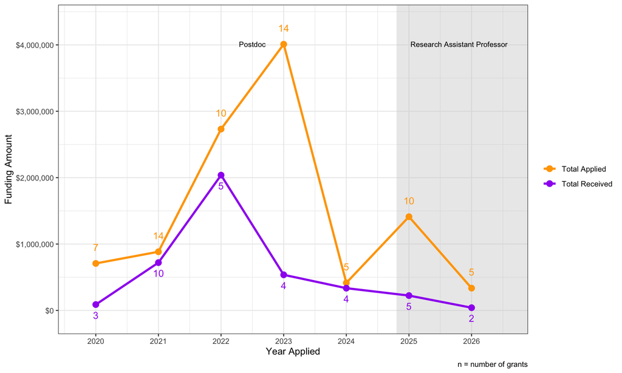

**Funding Year and Source**

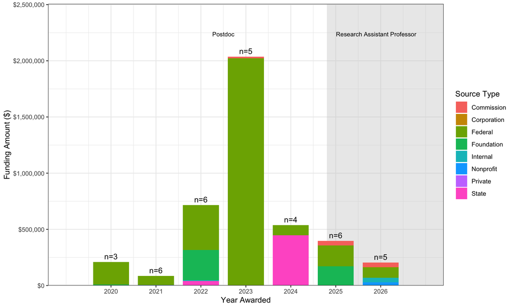

**Funded Project Duration Timeline**

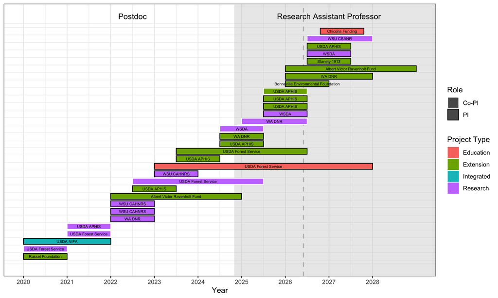